# SH_05_FORM_LINE_REFERENCE

Form, part, and line number reference · Text report

## Overview

**Description**

Form; part and line number reference

**Table**

`SH-P05-T99-SUPPLEMENTAL-INFO` (one)

**Location code**

`SCHED-H-PART-06`, `SCHED-H-PART-05-SECTION-C`

**Family**

`SCHED-H-PART-06` · siblings: SH_05_EXPLANATION_TEXT, SH_05_IDENTIFIER, SH_06_EXPLANATION_TEXT, SH_06_IDENTIFIER, SH_06_RETURN_REFERENCE

**Data type**

text (xsd: LineExplanationType)

**Scope**

PC

**Status**

unreviewed

2

xpaths mapped (2 observed)

53,329

filings with a value

2013–2024

tax years observed

3

open flags (1 errors)

## Flags

| Severity | Flag | Xpath | Detail |
| --- | --- | --- | --- |
| ⚠ error | `COLLISION` | IRS990ScheduleH/SupplementalInformationDetail/FormAndLineReferenceDesc | 26430 filings contain 2+ of its xpaths; most common set: /Return/ReturnData/IRS990ScheduleH/SupplementalInformationDetail/FormAndLineReferenceDesc ; /Return/ReturnData/IRS990ScheduleH/SupplementalInfo… |
| ▲ warn | `ONE_REPEATS` | IRS990ScheduleH/SupplementalInformationDetail/FormAndLineReferenceDesc | one-to-one table, repeats in 97.6% of filings (max 296 per filing) |
| ▲ warn | `ONE_REPEATS` | IRS990ScheduleH/SupplementalInformationGrp/FormAndLineReferenceDesc | one-to-one table, repeats in 95.2% of filings (max 174 per filing) |

## Xpaths

All mapped xpaths (under /Return/ReturnData or /Return/ReturnHeader), oldest first. Charts label each series by its xpath.

| Xpath | Form | Chart label | First year | Last year | Versions | Filings | Repeats in |
| --- | --- | --- | --- | --- | --- | --- | --- |
| IRS990ScheduleH/SupplementalInformationDetail/FormAndLineReferenceDesc | Sched H | …eH/SupplementalInformationDetail/FormAndLineReferenceDesc | 2013 | 2024 | 35 | 26,857 | 97.6% |
| IRS990ScheduleH/SupplementalInformationGrp/FormAndLineReferenceDesc | Sched H | …duleH/SupplementalInformationGrp/FormAndLineReferenceDesc | 2013 | 2024 | 35 | 26,472 | 95.2% |

## Coverage

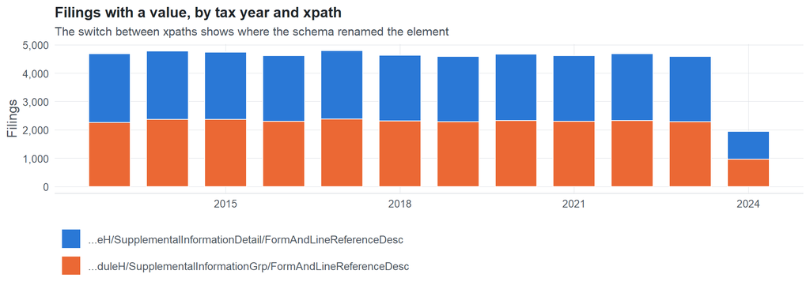

**Table view**

Table view: filings by tax year and series

| Tax year | …eH/SupplementalInformationDetail/FormAndLineReferenceDesc | …duleH/SupplementalInformationGrp/FormAndLineReferenceDesc |
| --- | --- | --- |
| 2013 | 2,427 | 2,259 |
| 2014 | 2,408 | 2,372 |
| 2015 | 2,379 | 2,360 |
| 2016 | 2,321 | 2,294 |
| 2017 | 2,405 | 2,381 |
| 2018 | 2,324 | 2,306 |
| 2019 | 2,303 | 2,286 |
| 2020 | 2,345 | 2,327 |
| 2021 | 2,317 | 2,302 |
| 2022 | 2,345 | 2,330 |
| 2023 | 2,305 | 2,286 |
| 2024 | 978 | 969 |

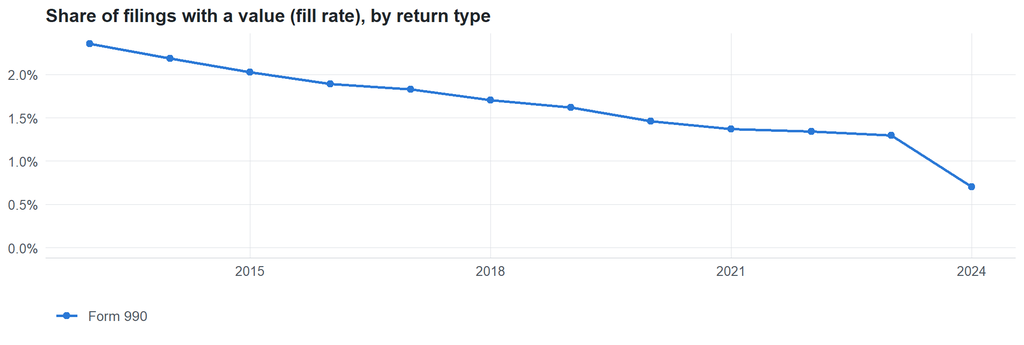

**Table view**

Table view: fill rate

| Tax year | Return type | Filings | All filings | Fill rate |
| --- | --- | --- | --- | --- |
| 2013 | Form 990 | 4,686 | 198,855 | 2.36% |
| 2014 | Form 990 | 4,780 | 218,619 | 2.19% |
| 2015 | Form 990 | 4,739 | 233,519 | 2.03% |
| 2016 | Form 990 | 4,615 | 243,903 | 1.89% |
| 2017 | Form 990 | 4,786 | 261,612 | 1.83% |
| 2018 | Form 990 | 4,630 | 271,442 | 1.71% |
| 2019 | Form 990 | 4,589 | 283,694 | 1.62% |
| 2020 | Form 990 | 4,672 | 320,342 | 1.46% |
| 2021 | Form 990 | 4,619 | 336,480 | 1.37% |
| 2022 | Form 990 | 4,675 | 349,055 | 1.34% |
| 2023 | Form 990 | 4,591 | 354,768 | 1.29% |
| 2024 | Form 990 | 1,947 | 277,298 | 0.70% |

## Repeating groups

Table cardinality in the concordance: **one**. 2 of 2 observed xpaths repeat within a filing.

Repeating element each xpath was observed in (from the raw indexed xpath)

| Xpath | Repeating element | Filings (summed over years) |
| --- | --- | --- |
| IRS990ScheduleH/SupplementalInformationDetail/FormAndLineReferenceDesc | (none) | 645 |
| IRS990ScheduleH/SupplementalInformationDetail/FormAndLineReferenceDesc | IRS990ScheduleH/SupplementalInformationDetail | 26212 |
| IRS990ScheduleH/SupplementalInformationGrp/FormAndLineReferenceDesc | (none) | 1282 |
| IRS990ScheduleH/SupplementalInformationGrp/FormAndLineReferenceDesc | IRS990ScheduleH/SupplementalInformationGrp | 25190 |

## Values

| Result | Check | Detail |
| --- | --- | --- |
| ✓ pass | Values are text, not numbers | 0% of values are numeric |
| ⓘ info | No sign of truncation | …eH/SupplementalInformationDetail/FormAndLineReferenceDesc: longest value is exactly 100 characters; …duleH/SupplementalInformationGrp/FormAndLineReferenceDesc: longest value is exactly 100 characters |
| ⓘ info | No dominant boilerplate value | most common value covers 38% of filings: “PART VI, LINE 4:” |

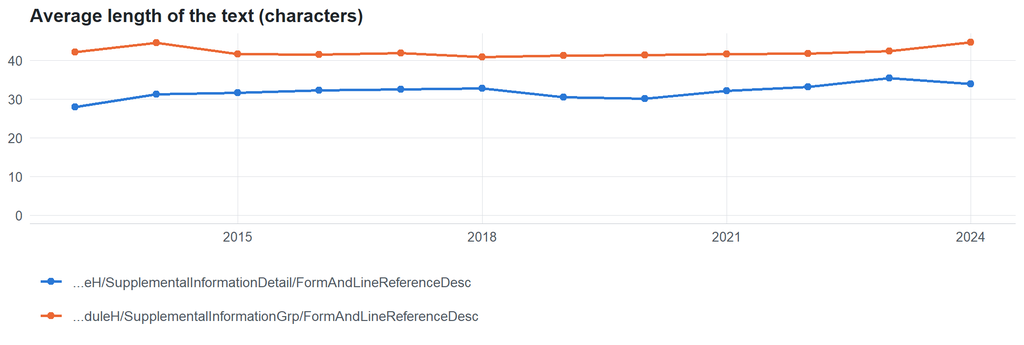

**Table view**

Table view: length and variety by tax year

| Series | Tax year | Filings | Avg length | Max length | Distinct values (approx.) |
| --- | --- | --- | --- | --- | --- |
| …eH/SupplementalInformationDetail/FormAndLineReferenceDesc | 2013 | 2,427 | 28 | 99 | 2,093 |
| …eH/SupplementalInformationDetail/FormAndLineReferenceDesc | 2014 | 2,408 | 31 | 100 | 2,008 |
| …eH/SupplementalInformationDetail/FormAndLineReferenceDesc | 2015 | 2,379 | 32 | 100 | 1,803 |
| …eH/SupplementalInformationDetail/FormAndLineReferenceDesc | 2016 | 2,321 | 32 | 100 | 1,726 |
| …eH/SupplementalInformationDetail/FormAndLineReferenceDesc | 2017 | 2,405 | 32 | 99 | 1,972 |
| …eH/SupplementalInformationDetail/FormAndLineReferenceDesc | 2018 | 2,324 | 33 | 100 | 1,242 |
| …eH/SupplementalInformationDetail/FormAndLineReferenceDesc | 2019 | 2,303 | 31 | 99 | 1,163 |
| …eH/SupplementalInformationDetail/FormAndLineReferenceDesc | 2020 | 2,345 | 30 | 100 | 1,233 |
| …eH/SupplementalInformationDetail/FormAndLineReferenceDesc | 2021 | 2,317 | 32 | 100 | 1,621 |
| …eH/SupplementalInformationDetail/FormAndLineReferenceDesc | 2022 | 2,345 | 33 | 100 | 1,747 |
| …eH/SupplementalInformationDetail/FormAndLineReferenceDesc | 2023 | 2,305 | 35 | 100 | 1,240 |
| …eH/SupplementalInformationDetail/FormAndLineReferenceDesc | 2024 | 978 | 34 | 100 | 590 |
| …duleH/SupplementalInformationGrp/FormAndLineReferenceDesc | 2013 | 2,259 | 42 | 100 | 2,999 |
| …duleH/SupplementalInformationGrp/FormAndLineReferenceDesc | 2014 | 2,372 | 45 | 94 | 4,704 |
| …duleH/SupplementalInformationGrp/FormAndLineReferenceDesc | 2015 | 2,360 | 42 | 94 | 3,321 |
| …duleH/SupplementalInformationGrp/FormAndLineReferenceDesc | 2016 | 2,294 | 42 | 94 | 2,686 |
| …duleH/SupplementalInformationGrp/FormAndLineReferenceDesc | 2017 | 2,381 | 42 | 94 | 4,840 |
| …duleH/SupplementalInformationGrp/FormAndLineReferenceDesc | 2018 | 2,306 | 41 | 92 | 3,548 |
| …duleH/SupplementalInformationGrp/FormAndLineReferenceDesc | 2019 | 2,286 | 41 | 92 | 2,411 |
| …duleH/SupplementalInformationGrp/FormAndLineReferenceDesc | 2020 | 2,327 | 41 | 95 | 2,231 |
| …duleH/SupplementalInformationGrp/FormAndLineReferenceDesc | 2021 | 2,302 | 42 | 95 | 3,563 |
| …duleH/SupplementalInformationGrp/FormAndLineReferenceDesc | 2022 | 2,330 | 42 | 95 | 4,391 |
| …duleH/SupplementalInformationGrp/FormAndLineReferenceDesc | 2023 | 2,286 | 42 | 100 | 2,704 |
| …duleH/SupplementalInformationGrp/FormAndLineReferenceDesc | 2024 | 969 | 45 | 92 | 2,155 |

Most common values by xpath (all years; long values truncated)

| Series | Value | Filings | Share |
| --- | --- | --- | --- |
| …eH/SupplementalInformationDetail/FormAndLineReferenceDesc | PART VI, LINE 4: | 10,247 | 38.2% |
| …eH/SupplementalInformationDetail/FormAndLineReferenceDesc | PART III, LINE 4: | 10,051 | 37.4% |
| …eH/SupplementalInformationDetail/FormAndLineReferenceDesc | PART VI, LINE 3: | 9,699 | 36.1% |
| …eH/SupplementalInformationDetail/FormAndLineReferenceDesc | PART III, LINE 9B: | 9,522 | 35.5% |
| …eH/SupplementalInformationDetail/FormAndLineReferenceDesc | PART VI, LINE 2: | 9,496 | 35.4% |
| …eH/SupplementalInformationDetail/FormAndLineReferenceDesc | PART III, LINE 8: | 9,358 | 34.8% |
| …eH/SupplementalInformationDetail/FormAndLineReferenceDesc | PART VI, LINE 5: | 9,195 | 34.2% |
| …eH/SupplementalInformationDetail/FormAndLineReferenceDesc | PART I, LINE 7: | 8,389 | 31.2% |
| …eH/SupplementalInformationDetail/FormAndLineReferenceDesc | PART VI, LINE 6: | 6,947 | 25.9% |
| …eH/SupplementalInformationDetail/FormAndLineReferenceDesc | PART III, LINE 2: | 6,205 | 23.1% |
| …eH/SupplementalInformationDetail/FormAndLineReferenceDesc | Part VI, Line 4: | 1,197 | 4.5% |
| …eH/SupplementalInformationDetail/FormAndLineReferenceDesc | Part VI, Line 3: | 1,192 | 4.4% |
| …eH/SupplementalInformationDetail/FormAndLineReferenceDesc | PART II, COMMUNITY BUILDING ACTIVITIES: | 1,116 | 4.2% |
| …eH/SupplementalInformationDetail/FormAndLineReferenceDesc | Part VI, Line 2: | 648 | 2.4% |
| …eH/SupplementalInformationDetail/FormAndLineReferenceDesc | Part III, Line 4: | 640 | 2.4% |
| …eH/SupplementalInformationDetail/FormAndLineReferenceDesc | Part III, Line 9b: | 632 | 2.4% |
| …eH/SupplementalInformationDetail/FormAndLineReferenceDesc | Part VI, Line 5: | 628 | 2.3% |
| …eH/SupplementalInformationDetail/FormAndLineReferenceDesc | Part III, Line 8: | 622 | 2.3% |
| …eH/SupplementalInformationDetail/FormAndLineReferenceDesc | Part I, Line 7: | 559 | 2.1% |
| …duleH/SupplementalInformationGrp/FormAndLineReferenceDesc | Schedule H, Part V, Section B, Line 5 Facility , 1 | 2,466 | 9.3% |
| …duleH/SupplementalInformationGrp/FormAndLineReferenceDesc | Schedule H, Part V, Section B, Line 11 Facility , 1 | 2,455 | 9.3% |
| …duleH/SupplementalInformationGrp/FormAndLineReferenceDesc | Schedule H, Part V, Section B, Line 3E | 1,814 | 6.9% |
| …duleH/SupplementalInformationGrp/FormAndLineReferenceDesc | Schedule H, Part V, Section B, Line 6a Facility , 1 | 1,480 | 5.6% |
| …duleH/SupplementalInformationGrp/FormAndLineReferenceDesc | Schedule H, Part V, Section B, Line 6b Facility , 1 | 1,173 | 4.4% |
| …duleH/SupplementalInformationGrp/FormAndLineReferenceDesc | SCHEDULE H, PART V, SECTION B, LINE 11 | 1,095 | 4.1% |
| …duleH/SupplementalInformationGrp/FormAndLineReferenceDesc | SCHEDULE H, PART V, SECTION B, LINE 5 | 1,078 | 4.1% |
| …duleH/SupplementalInformationGrp/FormAndLineReferenceDesc | PART V, SECTION B | 647 | 2.4% |
| …duleH/SupplementalInformationGrp/FormAndLineReferenceDesc | FACILITY REPORTING GROUP A CONSISTS OF: | 565 | 2.1% |
| …duleH/SupplementalInformationGrp/FormAndLineReferenceDesc | Schedule H, Part V, Section B, Line 13 Facility , 1 | 553 | 2.1% |
| …duleH/SupplementalInformationGrp/FormAndLineReferenceDesc | PART V, SECTION B, LINE 16 | 552 | 2.1% |

First rows shown.

## Examples

| Tax year | Return | Xpath | Organization | Value | Source |
| --- | --- | --- | --- | --- | --- |
| 2024 | 990 | IRS990ScheduleH/SupplementalInformationDetail/FormAndLineReferenceDesc | THE CLEVELAND CLINIC FOUNDATION | PART I, LINE 3C: | [XML](https://gt990datalake-rawdata.s3.amazonaws.com/EfileData/XmlFiles/202513189349302136_public.xml) |
| 2024 | 990 | IRS990ScheduleH/SupplementalInformationGrp/FormAndLineReferenceDesc | UNION HOSPITAL INC | PART V, SECTION B | [XML](https://gt990datalake-rawdata.s3.amazonaws.com/EfileData/XmlFiles/202503219349303730_public.xml) |
| 2023 | 990 | IRS990ScheduleH/SupplementalInformationDetail/FormAndLineReferenceDesc | Clay County Medical Corporation | Schedule H, Part I, Line 3c | [XML](https://gt990datalake-rawdata.s3.amazonaws.com/EfileData/XmlFiles/202502279349303290_public.xml) |
| 2023 | 990 | IRS990ScheduleH/SupplementalInformationGrp/FormAndLineReferenceDesc | ARH TUG VALLEY HEALTH SERVICES INC | PART V, LINE 16A, FAP WEBSITE: | [XML](https://gt990datalake-rawdata.s3.amazonaws.com/EfileData/XmlFiles/202511349349306946_public.xml) |
| 2022 | 990 | IRS990ScheduleH/SupplementalInformationDetail/FormAndLineReferenceDesc | RUSSELL HOSPITAL CORPORATION | SCHEDULE H, PART I, LINE 7 | [XML](https://gt990datalake-rawdata.s3.amazonaws.com/EfileData/XmlFiles/202333179349300113_public.xml) |
| 2022 | 990 | IRS990ScheduleH/SupplementalInformationGrp/FormAndLineReferenceDesc | SOUTHWEST HEALTH CENTER INC | PART V, SECTION B | [XML](https://gt990datalake-rawdata.s3.amazonaws.com/EfileData/XmlFiles/202420659349300532_public.xml) |
| 2021 | 990 | IRS990ScheduleH/SupplementalInformationDetail/FormAndLineReferenceDesc | TRI-COUNTY MEMORIAL HOSPITAL INC | PART I, LINE 3C: | [XML](https://gt990datalake-rawdata.s3.amazonaws.com/EfileData/XmlFiles/202243199349308309_public.xml) |
| 2021 | 990 | IRS990ScheduleH/SupplementalInformationGrp/FormAndLineReferenceDesc | IRA DAVENPORT MEMORIAL HOSPITAL INC | Schedule H, Part V, Section B, Line 5-IRA DAVENPORT MEMORIAL HOSPITAL | [XML](https://gt990datalake-rawdata.s3.amazonaws.com/EfileData/XmlFiles/202203199349328110_public.xml) |
| 2020 | 990 | IRS990ScheduleH/SupplementalInformationDetail/FormAndLineReferenceDesc | Memorial Hospital Association | Part I, Line 3c: | [XML](https://gt990datalake-rawdata.s3.amazonaws.com/EfileData/XmlFiles/202133139349303608_public.xml) |
| 2020 | 990 | IRS990ScheduleH/SupplementalInformationGrp/FormAndLineReferenceDesc | Southeast Volusia Healthcare Corporation | Southeast Volusia Healthcare Corporation | [XML](https://gt990datalake-rawdata.s3.amazonaws.com/EfileData/XmlFiles/202103199349312315_public.xml) |
| 2019 | 990 | IRS990ScheduleH/SupplementalInformationDetail/FormAndLineReferenceDesc | Bartow Regional Medical Center Inc | Schedule H, Part VI, Line 7 State filing of community benefit report | [XML](https://gt990datalake-rawdata.s3.amazonaws.com/EfileData/XmlFiles/202042969349301439_public.xml) |
| 2019 | 990 | IRS990ScheduleH/SupplementalInformationGrp/FormAndLineReferenceDesc | Bartow Regional Medical Center Inc | Schedule H, Part V, Section B, Line 5 Facility , 1 | [XML](https://gt990datalake-rawdata.s3.amazonaws.com/EfileData/XmlFiles/202042969349301439_public.xml) |

## Reviewer checklist

- The definition matches the form line and instructions for every xpath’s schema years.
- Every xpath pooled here measures the same thing on the 990 and 990-EZ (close enough for analysis).
- The coverage chart has no unexplained gaps or jumps between tax years.
- Each open flag is fixed, or accepted with a note in validation_log.csv.
- Values answer the question on the form line (not another line’s explanation).
- Boilerplate such as ‘See Schedule O’ or ‘N/A’ is expected here, or should be treated as missing.
- Text that is really a number or a code is flagged for a different data type.

Record the review as a row in `inst/extdata/src/validation_log.csv` (variable_name, reviewer, date, status, note). Evidence built 2026-09-23 17:09:04 MST from the ef2 DuckDB builds (tax years 2009–2024).